# Phi Data

Ericka Smith

12/3/2020

This is the script I used to figure out how to get phi data added to our length data. It includes various QC checks

load libraries

```r
library(tidyverse)
library(here)
library(leaderCluster)
```

load data

```r
catch <- read_csv(here("data", "Shelf_Flatfish_Haul_Catch.csv"), guess_max = 10000)
phi <- read_csv(here("data", "Arrowtooth_Eastern_BS_has_Phi.csv"), guess_max = 10000)
```

I hate uppercase

```r
make_lowercase <- function(df){
  for (i in 1:length(names(df))){
    names(df)[i] <- tolower(names(df)[i])
  }
  return(df)
}

catch <- make_lowercase(catch)
```

filter catch so that it goes 2000 to 2010 and only includes hauls 1-300 then create year var and get rid of all vars except haul, lat, long, stationid, and year

```r
catch_filter <- catch %>%
  filter(cruise>=200000 & cruise <=201001,
         region=="BS",
         haul <=300) %>%
  mutate(year=floor((cruise/100))) %>%
  select(haul, start_latitude, start_longitude, stationid,year)
```

filter phi so it only includes 2000 to 2010 get rid of unnecessary columns

```r
phi_filter <- phi%>%
  filter(year>=2000 & year <=2010)%>%
  select(haul, year, lat, lon, phi)

# create an even small phi
phi_dat <- phi[,c("lat","lon")]

# make a matrix of phi
phi_mat <- matrix(c(phi_dat$lat,phi_dat$lon), ncol=2)
```

get cluster ids for spatial subsetting

```r
clusts <- leaderCluster(points=phi_mat, radius=.175)

# add cluster ids to shorty phi data
phi_dat <- phi_dat %>%
  mutate(clust_id = factor(clusts$cluster_id))
```

plot a small amount to see if clusters are correct

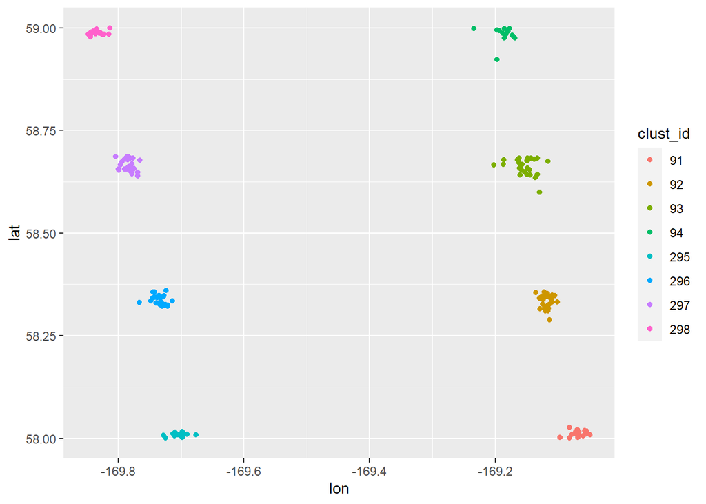

```r
phi_dat %>%
  filter(lon >(-170) &lon<(-169),
         lat >58 & lat <59) %>%
  ggplot()+
  geom_point(aes(x=lon, y=lat, color=clust_id))
```

plot all together to see if it worked

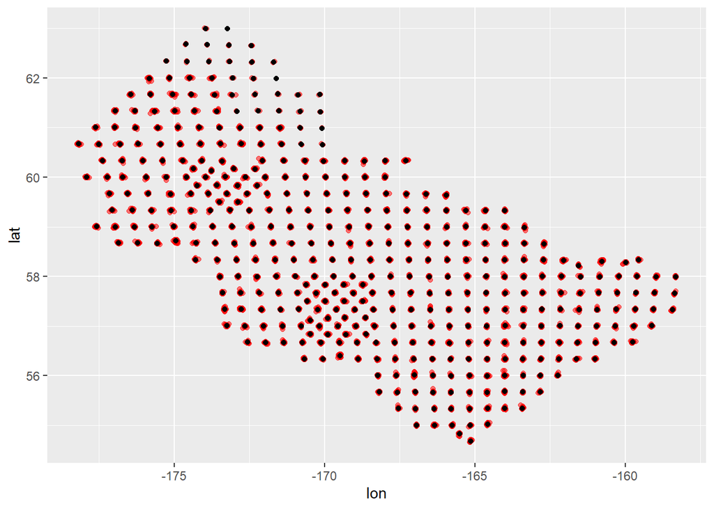

```r
compare_phi_clust <- phi_dat %>%
  group_by(clust_id) %>%
  summarise_at(vars(lat:lon), mean, na.rm=TRUE)

ggplot()+
  geom_point(data=phi_dat, aes(x=lon, y=lat), color="red", alpha=0.5)+
  geom_point(data=compare_phi_clust, aes(x=lon, y=lat))
```

## it worked!

now to add that back to length data… get phi matched up with hauljoin vars first check if year matters or if we can just average phi oops just realized I used the phi that isn’t filtered to only be 2000-2010

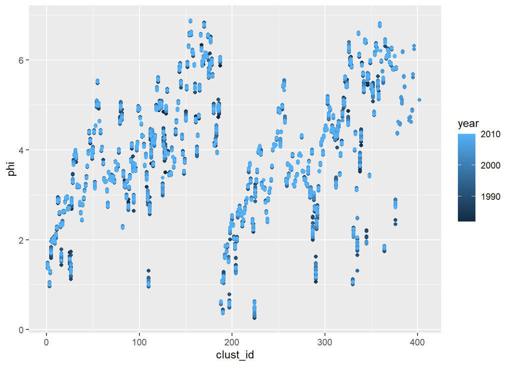

```r
phi_all_together <- phi %>%
  mutate(clust_id = clusts$cluster_id)

ggplot(phi_all_together)+
  geom_point(aes(x=clust_id, y=phi, color=year))
```

… not sure what that tells me

## Let’s try again with the overlap years

```r
phi_dat <- phi_filter[,c("lat","lon")]

# make a matrix of phi
phi_mat <- matrix(c(phi_dat$lat,phi_dat$lon), ncol=2)

# get cluster ids for spatial subsetting
clusts <- leaderCluster(points=phi_mat, radius=.175)

# add cluster ids to shorty phi data
phi_dat <- phi_dat %>%
  mutate(clust_id = factor(clusts$cluster_id))
```

plot a small amount to see if clusters are correct

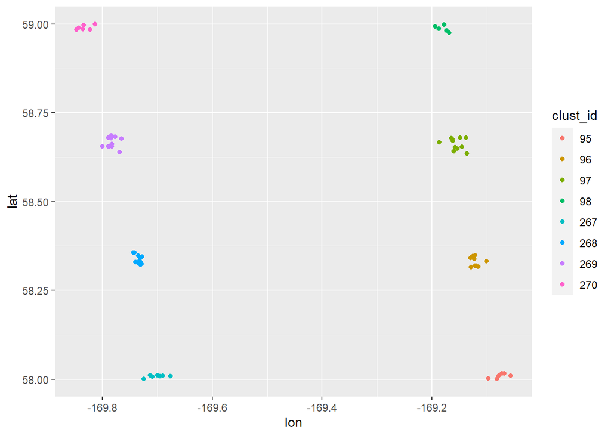

```r
phi_dat %>%
  filter(lon >(-170) &lon<(-169),
         lat >58 & lat <59) %>%
  ggplot()+
  geom_point(aes(x=lon, y=lat, color=clust_id))
```

plot all together to see if it worked

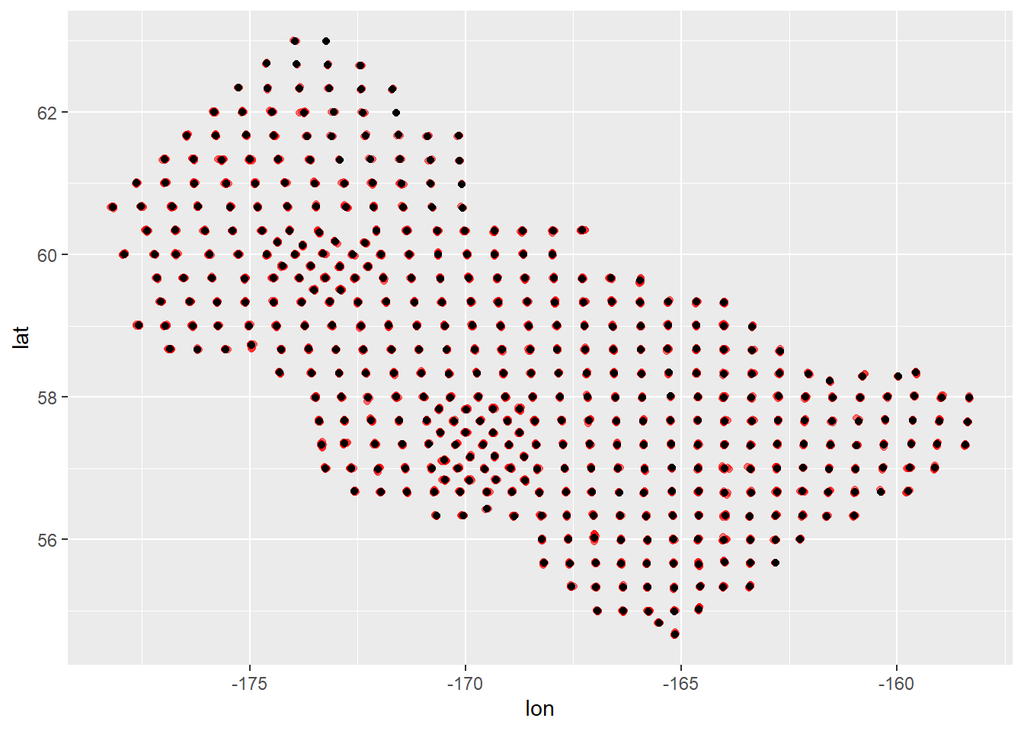

```r
compare_phi_clust <- phi_dat %>%
  group_by(clust_id) %>%
  summarise_at(vars(lat:lon), mean, na.rm=TRUE)

ggplot()+
  geom_point(data=phi_dat, aes(x=lon, y=lat), color="red", alpha=0.5)+
  geom_point(data=compare_phi_clust, aes(x=lon, y=lat))
```

Cool, first part still looks correct, as expected.

Back to trying to see if year matters for phi

```r
phi_all_together <- phi_filter %>%
  mutate(clust_id = clusts$cluster_id,
         year = factor(year))
```

create a range variable for ranges of phi at a cluster over the years

```r
phi_ranges <- phi_all_together %>%
  group_by(clust_id) %>%
  summarise(rang = range(phi, na.rm=TRUE)[2]-range(phi, na.rm = TRUE)[1])
```

make a boxplot with all phi vals and a boxplot with all phi ranges

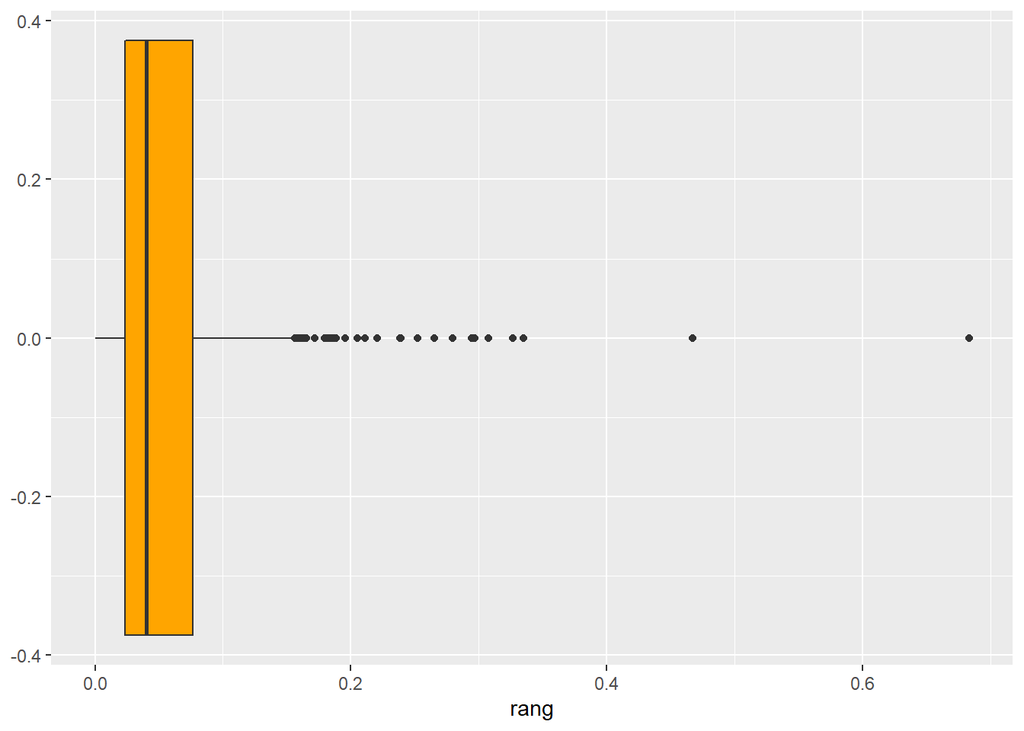

```r
ggplot()+
  geom_boxplot(data=phi_ranges, aes(x=rang), fill="orange")
```

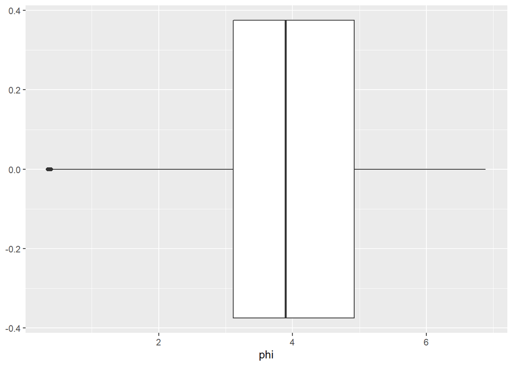

```r
ggplot(phi_all_together)+
  geom_boxplot(aes(x=phi))
```

determine which clusters have “large” ranges for phi

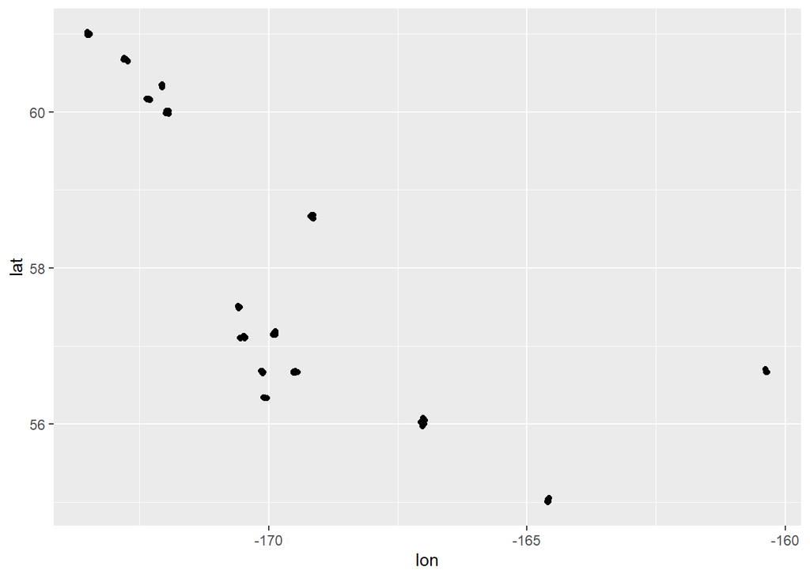

```r
large_range_clust_ids <- phi_ranges$clust_id[which(phi_ranges$rang >0.2)]

phi_all_together %>%
  filter(clust_id %in% large_range_clust_ids) %>%
  ggplot()+
  geom_point(aes(x=lon, y=lat))
```

looks as though “large” isn’t that large (I think) AND as though there isn’t a specific place that has “large” ranges (?) so I’m going to average phi values over the years

## So phi from start to finish should look like this:

```r
phi <- read_csv(here("data", "Arrowtooth_Eastern_BS_has_Phi.csv"), guess_max = 10000)
phi_filter <- phi %>%
  filter(year>=2000 & year <=2010)%>%
  select(haul, year, lat, lon, phi)

phi_mat <- matrix(c(phi_filter$lat,phi_filter$lon), ncol=2)

phi_clusts <- leaderCluster(points=phi_mat, radius=.175)

phi_centroids <- data.frame(clust_id = factor(seq(1, 405, by=1)),
                        group_lat = phi_clusts$cluster_centroids[,1],
                        group_lon = phi_clusts$cluster_centroids[,2])

phi_final <- phi_filter %>%
  mutate(clust_id = factor(clusts$cluster_id)) %>%
  left_join(phi_centroids, by="clust_id")
```

## Now to attach phi to length data

get length data in (just copied from `data_initial.R`) :

going to try just getting clusters from it. working straight from `len_extended` created by `data_initial.R`

```r
len_filtered <- len_extended %>%
  select(hauljoin, start_latitude, start_longitude)

len_mat <- matrix(c(len_filtered$start_latitude,
                    len_filtered$start_longitude),
                  ncol=2)

len_clusts <- leaderCluster(points = len_mat, radius = 0.175)
length_centroids <- data.frame(clust_id = factor(seq(1, 666, by=1)),
                        group_lat = len_clusts$cluster_centroids[,1],
                        group_lon = len_clusts$cluster_centroids[,2])

len_final <- len_filtered %>%
  mutate(clust_id = factor(len_clusts$cluster_id)) %>%
  left_join(length_centroids, by= "clust_id")
```

There are 666 clusters for length data and 405 for phi, lets see how different they look

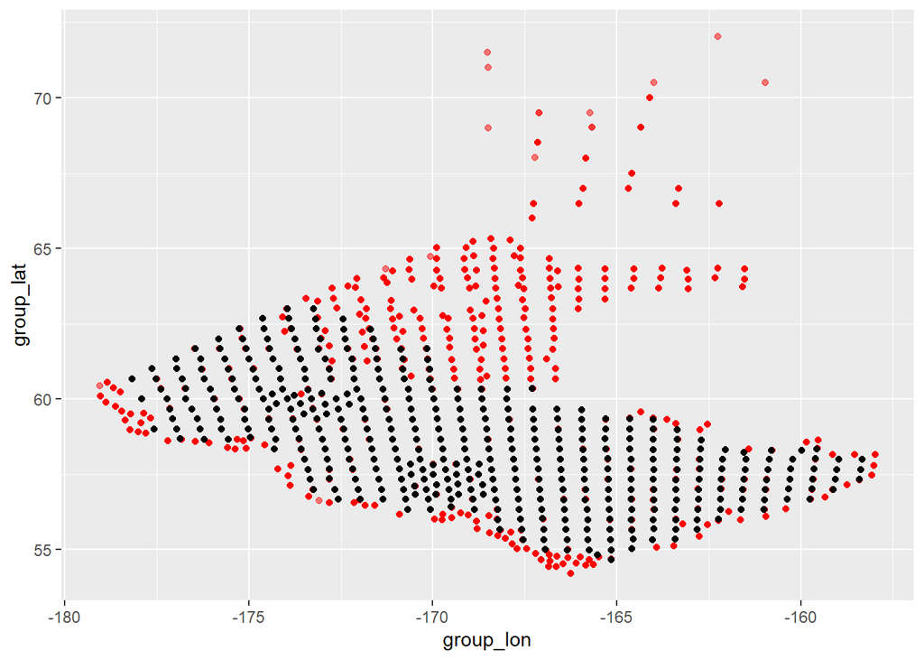

```r
ggplot()+
  geom_point(data=len_final, aes(x=group_lon, y=group_lat), color="red", alpha=0.5)+
  geom_point(data=phi_final, aes(x=group_lon, y=group_lat))
```

So we just don’t have phi for some of the points. What if I try limiting length data to 2000-2010?

```r
len_2000_2010 <- len_extended %>%
  filter(year >=2007 & year <=2008) %>%
  select(hauljoin, start_latitude, start_longitude)

len_mat_2000_2010 <- matrix(c(len_2000_2010$start_latitude,
                    len_2000_2010$start_longitude),
                  ncol=2)

len_clusts_2000_2010 <- leaderCluster(points = len_mat_2000_2010, radius = 0.175)
length_centroid_2000_2010 <- data.frame(clust_id = factor(seq(1, len_clusts_2000_2010$num_clusters, by=1)),
                        group_lat = len_clusts_2000_2010$cluster_centroids[,1],
                        group_lon = len_clusts_2000_2010$cluster_centroids[,2])

len_final_2000_2010 <- len_2000_2010 %>%
  mutate(clust_id = factor(len_clusts_2000_2010$cluster_id)) %>%
  left_join(length_centroid_2000_2010, by= "clust_id")
```

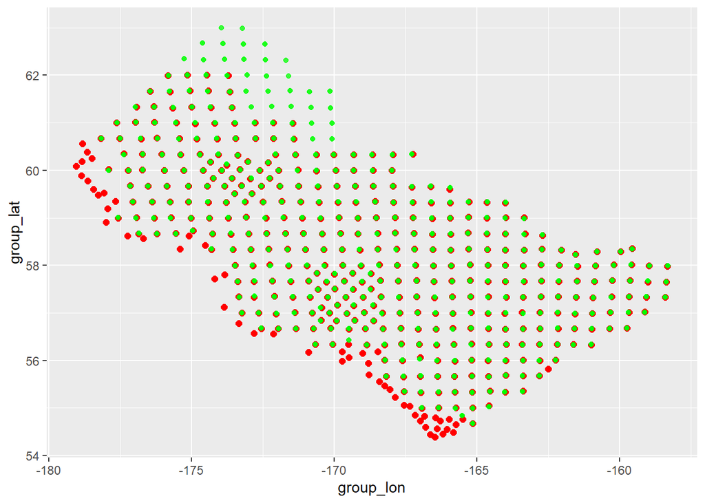

```r
ggplot()+
  geom_point(data=len_final_2000_2010, aes(x=group_lon, y=group_lat), color="red", size=2)+
  geom_point(data=phi_final, aes(x=group_lon, y=group_lat), color="green", alpha=0.5)
```

Closer. Trying rerunning the above with different years based on what I see in `src/work_sessions/Jul212020_initial_EDA_II/html`

2010 way too big 2008 a little too big 2007 too small 2005 missing a random line

## Think this is the wrong direction.

I have average phi for centroid lat and lon values from arrowtooth dataset, so that’s good. moving forward with that.